# Matplotlib

Pour tracer des figures, afin de visualiser nos données, on utilise le package $\textbf{pyplot}$ qui se trouve dans $\textbf{matplotlib}$ On commence par l'importer come suit:

```python
import matplotlib.pyplot as plt
```

Il existe deux methodes pour la représentation des donnees:

- la méthode : $\textbf{plt.plot()}$
- et la méthode de la promgrammation orientée objet (POO) $\textbf{fig, ax = plt.subplots()}$

## 1- Methode plt.plot()

Notre première figure. Remarque :

- pour afficher les images dans la console, on ecrit dans une des cellules au moins une fois la ligne $\textbf{%matplotlib inline}$
- Pour sortir la figure, on ecrit plutôt $\textbf{%matplotlib qt5}$

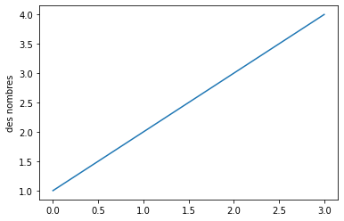

```python
%matplotlib inline


plt.plot([1,2,3,4])
plt.ylabel("des nombres")
plt.show()
```

Remarque : Si la fonction plot reçoit un tableau de données, elle l'utilisera comme coordonnées sur l'axe vertical, et elle utilisera simplement l'index de chaque point de données dans le tableau comme coordonnée horizontale.

Vous pouvez également fournir deux tableaux : un pour l'axe horizontal x, et le second pour l'axe vertical y :

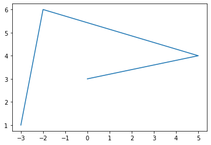

```python
plt.plot([-3,-2,5,0],[1,6,4,3])
plt.show()
```

Les axes correspondent automatiquement à l'étendue des données. Nous aimerions donner un peu plus d'espace au graphique, alors appelons la fonction $\textbf{axis}$ pour modifier l'étendue de chaque axe $\textbf{[xmin, xmax, ymin, ymax]}$.

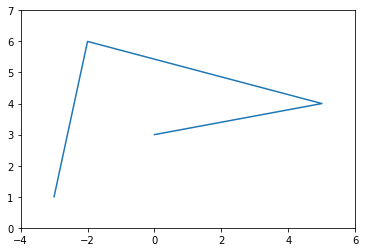

```python
plt.plot([-3,-2,5,0],[1,6,4,3])
plt.axis([ -4 ,6, 0, 7])
plt.show()
```

On peut tracer plusieurs fonctions sur la meme figure. Il est recommender d'utiliser $\textbf{plt.figure}$ pour pouvoir definir la taille de sa figure.

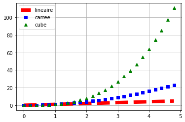

```python
import numpy as np

t = np.arange(0., 5., 0.2)
t

plt.plot(t,t,'r--', label='lineaire',lw = 7)
plt.plot(t,t**2,'bs', label= 'carree')
plt.plot(t,t**3,'g^', label='cube')
plt.grid()
plt.legend()
plt.show()

plt.savefig('ma_figure.png')
```

Un autre exemple ave la fonction carrée en utilisant LaTex dans les labels

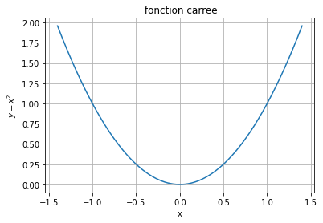

```python
x = np.linspace(-1.4,1.4,500) # je genere 500 valeurs entre -1.4 et 1.4
y =x**2

plt.plot(x,y)
plt.title(" fonction carree")
plt.xlabel("x")
plt.ylabel("$y = x^2$")
plt.grid()
plt.show()
```

Par défaut, matplotlib dessine une ligne entre des points consécutifs. On peut par exemple avoir ce type de dessin

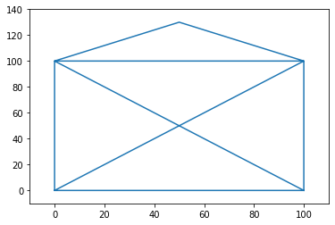

```python
#on s'amuse à dessiner une enveloppe

plt.plot([0,100,100,0,0,100,50,0,100],[0,0,100, 100,0,100,130,100,0])
plt.axis([-10,110, -10,140])

plt.show()
```

Un autre exemple avec un type de trait et de couleur différent

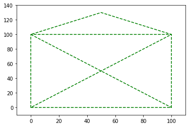

```python
plt.plot([0, 100, 100, 0, 0, 100, 50, 0, 100], [0, 0, 100, 100, 0, 100, 130, 100, 0], "g--")
plt.axis([-10, 110, -10, 140])
plt.show()
```

On peut avoir les deux types de traits

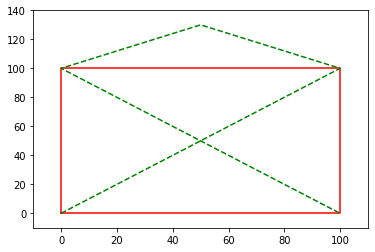

```python
plt.figure()
plt.plot([0, 100, 100, 0, 0], [0, 0, 100, 100, 0], "r-")
plt.plot([0, 100, 50, 0, 100], [0, 100, 130, 100, 0], "g--")
plt.axis([-10, 110, -10, 140])
plt.show()
```

### Subplot

Une figure matplotlib peut contenir plusieurs sous-plans. Ces sous-plots sont organisés dans une grille. Pour créer un sous-plot, il suffit d'appeler la fonction subplot, et de spécifier le nombre de lignes et de colonnes de la figure, ainsi que l'indice du sous-plot sur lequel vous souhaitez dessiner (en commençant par 1, puis de gauche à droite, et de haut en bas)

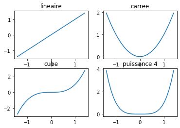

```python
x = np.linspace(-1.4,1.4,30)

plt.subplot(2,2,1)
plt.plot(x,x)
plt.title('lineaire')

plt.subplot(2,2,2)
plt.plot(x,x**2)
plt.title('carree')

plt.subplot(2,2,3)
plt.plot(x,x**3)
plt.title('cube')

plt.subplot(2,2,4)
plt.plot(x,x**4)
plt.title('puissance 4')

plt.show()
```

Notez que $\textbf{subplot(223)}$ est un raccourci pour $\textbf{subplot(2, 2, 3)}$.

On peut aussi créer des sous-plots qui s'étendent sur plusieurs cellules de la grille, comme suit :

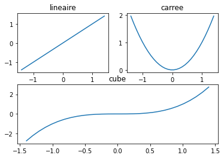

```python
plt.subplot(2,2,1)
plt.plot(x,x)
plt.title('lineaire')

plt.subplot(2,2,2)
plt.plot(x,x**2)
plt.title('carree')

plt.subplot(2,1,2)
plt.plot(x,x**3)
plt.title('cube')
plt.show()
```